# Quarterly Water Quality Surveys - Salton Sea [ds429]

Bodhi Hueffmeier

2025-04-11

# Sampling Methods Overview

Beginning in spring 2003, the California Department of Fish and Game (CDFG) initiated a long-term monitoring program involving quarterly fish sampling at multiple stations across the Salton Sea. Water quality data were collected simultaneously at each sampling location. (Note: This dataset is designed to be used alongside the Quarterly Fishery Surveys - Salton Sea [ds428].)

### The survey initially included 14 stations across three main habitat types:

```
•   Pelagic (open water): 3 sites located in the central regions of the north basin, south basin, and inter-basin.
•   Near-shore: 8 sites distributed along both the east and west shores.
•   Estuarine: 3 sites near the mouths of the New, Alamo, and Whitewater Rivers, where river inflow influences habitat conditions.
```

Due to a lack of fish capture during the first year, the three deep-water pelagic sites were removed from the sampling protocol in later years.

### Sampling was conducted seasonally:

```
•   Spring – April to May
•   Summer – July to August
•   Fall – October to November
•   Winter – January to February
```

Each sampling event aimed to take place over a condensed time frame, depending on weather, equipment availability, and staffing. Gill nets were deployed for approximately 24 hours at each site. During net setting and retrieval, environmental parameters—including water temperature, conductivity, specific conductivity, dissolved oxygen, and depth—were recorded using a YSI Model 85 meter.

[Quarterly Water Quality Surveys - Salton Sea [ds429]](https://data.cnra.ca.gov/dataset/quarterly-water-quality-surveys-salton-sea-ds429)

### Setting up the libraries, working directory, and data

```r
library(readr) # For reading CSV files
library(tidyverse) # For data manipulation
```

```r
library(dplyr) # For data manipulation
library(ggplot2) # For data manipulation and visualization
library("ggbreak") # For creating breaks in the x or y axes
library("patchwork") # For creating breaks in the x or y axes
library(knitr) # For creating tables
library(kableExtra) # For creating tables
setwd("~/Desktop/Universal Folder/Data Analysis Projects/Salton Sea [ds429]/Quarterly_Fishery_and_Water_Quality_Surveys_-_Salton_Sea (ds428)")

water_dat <- read_csv("Quarterly_Water_Quality_Surveys_-_Salton_Sea_[ds429].csv")
str(water_dat)
```

```
## spc_tbl_ [472 × 14] (S3: spec_tbl_df/tbl_df/tbl/data.frame)
##  $ X         : num [1:472] -12917368 -12917368 -12918979 -12906353 -12918979 ...
##  $ Y         : num [1:472] 3952583 3952583 3962129 3964287 3962129 ...
##  $ OBJECTID  : num [1:472] 1 2 3 4 5 6 7 8 9 10 ...
##  $ DATE_     : chr [1:472] "2008/07/07 00:00:00+00" "2008/07/08 00:00:00+00" "2008/07/08 00:00:00+00" "2008/07/09 00:00:00+00" ...
##  $ SITE      : chr [1:472] "North Desert Shores" "North Desert Shores" "Whitewater River" "North Shore" ...
##  $ PROBE     : chr [1:472] "4" "4" "4" "4" ...
##  $ TEMP_C    : chr [1:472] "32.7" "31.7" "33.6" "32.3" ...
##  $ CONDUCTIVI: chr [1:472] "64.7" "66.5" "70.69" "67.5" ...
##  $ SP_CONDUCT: chr [1:472] "56.9" "59" "60.6" "59.3" ...
##  $ SALINITY  : chr [1:472] "37.8" "39.4" "40.3" "39.5" ...
##  $ DISS_OXYGE: chr [1:472] "5.3" "2" "2.2" "3.9" ...
##  $ COMMENTS  : chr [1:472] NA NA NA NA ...
##  $ UTM_E     : num [1:472] 589366 589366 587948 598465 587948 ...
##  $ UTM_N     : num [1:472] 3699424 3699424 3707343 3709237 3707343 ...
##  - attr(*, "spec")=
##   .. cols(
##   ..   X = col_double(),
##   ..   Y = col_double(),
##   ..   OBJECTID = col_double(),
##   ..   DATE_ = col_character(),
##   ..   SITE = col_character(),
##   ..   PROBE = col_character(),
##   ..   TEMP_C = col_character(),
##   ..   CONDUCTIVI = col_character(),
##   ..   SP_CONDUCT = col_character(),
##   ..   SALINITY = col_character(),
##   ..   DISS_OXYGE = col_character(),
##   ..   COMMENTS = col_character(),
##   ..   UTM_E = col_double(),
##   ..   UTM_N = col_double()
##   .. )
##  - attr(*, "problems")=<externalptr>
```

TEMP_C, CONDUCTIVI, SP_CONDUCT, SALINITY, DISS_OXYGE have their data type classified as charters because “N/A” was in the CSV file. All of these columns will be have the “N/A” values converted to “NA” values and those data will be classified as doubles.

```r
cols_to_convert <- c("TEMP_C", "CONDUCTIVI", "SP_CONDUCT", "SALINITY", "DISS_OXYGE")

water_dat <- water_dat %>%
  mutate(across(all_of(cols_to_convert), ~ as.double(na_if(., "N/A"))))  # changing all of the columns listed in the cols_to_convert object as numeric and if any "N/A" value is present it is then converted to NA as a numbers
str(water_dat)
```

```
## tibble [472 × 14] (S3: tbl_df/tbl/data.frame)
##  $ X         : num [1:472] -12917368 -12917368 -12918979 -12906353 -12918979 ...
##  $ Y         : num [1:472] 3952583 3952583 3962129 3964287 3962129 ...
##  $ OBJECTID  : num [1:472] 1 2 3 4 5 6 7 8 9 10 ...
##  $ DATE_     : chr [1:472] "2008/07/07 00:00:00+00" "2008/07/08 00:00:00+00" "2008/07/08 00:00:00+00" "2008/07/09 00:00:00+00" ...
##  $ SITE      : chr [1:472] "North Desert Shores" "North Desert Shores" "Whitewater River" "North Shore" ...
##  $ PROBE     : chr [1:472] "4" "4" "4" "4" ...
##  $ TEMP_C    : num [1:472] 32.7 31.7 33.6 32.3 32.5 32.8 32 32.2 31.8 30.5 ...
##  $ CONDUCTIVI: num [1:472] 64.7 66.5 70.7 67.5 69.1 ...
##  $ SP_CONDUCT: num [1:472] 56.9 59 60.6 59.3 60.4 62.2 57.5 60.5 60 58.5 ...
##  $ SALINITY  : num [1:472] 37.8 39.4 40.3 39.5 40.3 41.6 38.1 40.4 39.9 38.9 ...
##  $ DISS_OXYGE: num [1:472] 5.3 2 2.2 3.9 2 5.3 5.5 4.7 2.4 3.6 ...
##  $ COMMENTS  : chr [1:472] NA NA NA NA ...
##  $ UTM_E     : num [1:472] 589366 589366 587948 598465 587948 ...
##  $ UTM_N     : num [1:472] 3699424 3699424 3707343 3709237 3707343 ...
```

### Adding in a variable called Date and having the data type in the date format

```r
water_dat <- water_dat %>%
  mutate(Date = as.Date(ymd_hms(water_dat$DATE_)))
```

### Sality Over Time

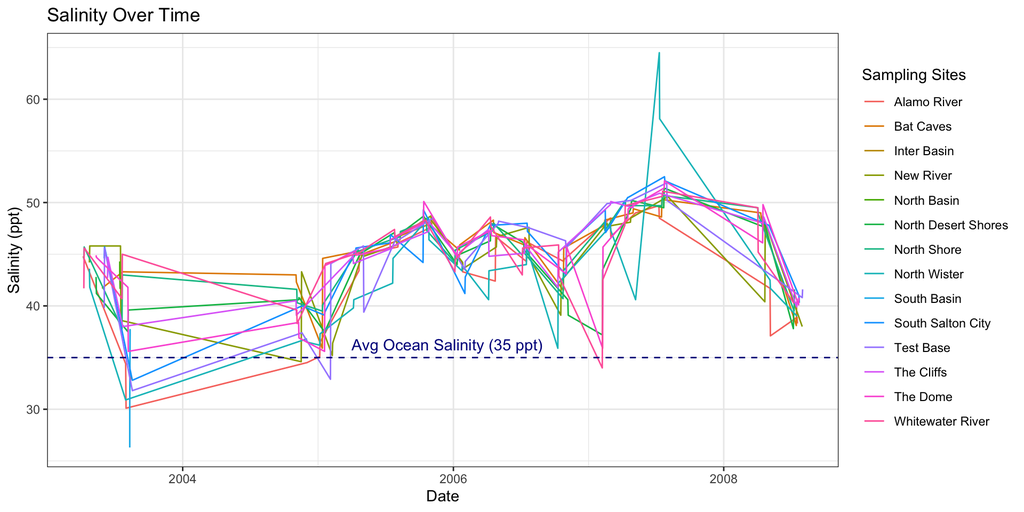

```r
no_na_salinity <- water_dat %>%     # Removing NAs from the water data
  drop_na(SALINITY)

salinity_time <- ggplot(data = no_na_salinity, aes(x = Date, y = SALINITY, color = SITE)) +
  geom_line() +
  geom_hline(yintercept = 35, linetype = "dashed", color = "darkblue") +
  annotate("text", x = as.Date("2005-04-01"), y = 35.5,
           label = "Avg Ocean Salinity (35 ppt)",
           color = "darkblue", hjust = 0, vjust = -0.2) +
  theme_bw() +
  ggtitle("Salinity Over Time") +
  ylab("Salinity (ppt)") +
  labs(color = "Sampling Sites")

salinity_time
```

The average salinity of the ocean is typically around 35 grams of salt per kilogram (g/kg) of seawater according to [USGS, 2022-03-14](https://www.usgs.gov/faqs/why-ocean-salty#:~:text=The%20concentration%20of%20salt%20in,comes%20from%20the%20dissolved%20salts.)

```r
# Create the data frame
salinity_table <- data.frame(
  Species = c("Tilapia", "Sargo", "Orangemouth Corvina", "Gulf Croaker"),
  `Eggs/Larvae` = c("75-95 (max), 35-65 (optimal)",
                    "40 (max), 33-37 (optimal)",
                    "40 (max), 33-37 (optimal)",
                    "40 (max), 15-40"),
  Juveniles = c("75-95 (max), 35-65 (optimal)",
                "45 (max)",
                "45 (max)",
                "45 (max)"),
  Adults = c("75-95 (max), 35-65 (optimal)",
             "45-55 (max), No Spawning",
             "50-55 (max)",
             "55-57 (max)")
)

# Create a kable table
kable(salinity_table, format = "html", escape = FALSE, caption = "Salinity Tolerance (‰) of Selected Fish Species in Different Life Stages") %>%
  kable_styling(bootstrap_options = c("striped", "hover", "condensed", "responsive"))
```

Salinity Tolerance (‰) of Selected Fish Species in Different Life Stages

| Species | Eggs.Larvae | Juveniles | Adults |
| --- | --- | --- | --- |
| Tilapia | 75-95 (max), 35-65 (optimal) | 75-95 (max), 35-65 (optimal) | 75-95 (max), 35-65 (optimal) |
| Sargo | 40 (max), 33-37 (optimal) | 45 (max) | 45-55 (max), No Spawning |
| Orangemouth Corvina | 40 (max), 33-37 (optimal) | 45 (max) | 50-55 (max) |
| Gulf Croaker | 40 (max), 15-40 | 45 (max) | 55-57 (max) |

[SALTON SEA ECOSYSTEM RESTORATION PLAN, 2005](https://nrm.dfg.ca.gov/FileHandler.ashx?DocumentID=8905) provides information on the salinity tolerances of various fish species in the Salton Sea. The table above summarizes the salinity tolerances for different life stages of selected fish species, including Tilapia, Sargo, Orangemouth Corvina, and Gulf Croaker.

### Temperature Over Time

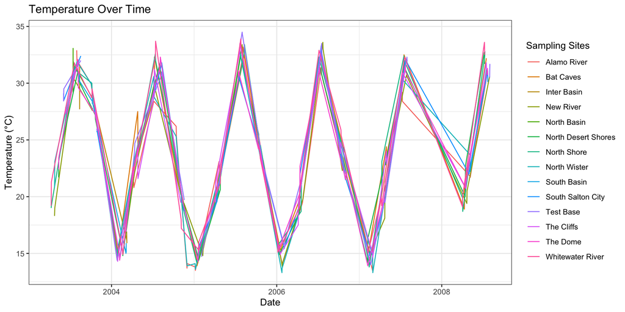

```r
temp_time <- ggplot(data = water_dat, aes(x = Date, y = TEMP_C, color = SITE)) +
  geom_line() +
  ggtitle("Temperature Over Time") +
  ylab("Temperature (°C)") +
  labs(color = "Sampling Sites") +
  theme_bw()

temp_time
```

Temperature is measured in degrees Celsius (°C) and the average temperature of the ocean is around 17 °C according to [NOAA, 2022-03-14](https://oceanservice.noaa.gov/facts/temperature.html).

```r
# Create the data frame
fish_temp <- data.frame(
  Species = c("Tilapia", "Orangemouth Corvina", "Gulf Croaker", "Sargo"),
  `Optimal Temperature Range` = c("75–86°F (24–30°C)", "Not specified", "Not specified", "Not specified"),
  `Stress Thresholds` = c("Below 68°F (20°C): Stress", "Not specified", "Not specified", "Not specified"),
  `Lethal Limits` = c("Below 50°F (10°C): Lethal", "Not specified", "Not specified", "Not specified"),
  Source = c(
    "[Grower Today](https://growertoday.com/tilapia-temperature-requirements/)",
    "[CDFW](https://nrm.dfg.ca.gov/FileHandler.ashx?DocumentID=8905)",
    "[CDFW](https://nrm.dfg.ca.gov/FileHandler.ashx?DocumentID=8905)",
    "[CDFW](https://nrm.dfg.ca.gov/FileHandler.ashx?DocumentID=8905)"
  )
)

# Create a kable table
kable(fish_temp, format = "html", escape = FALSE, caption = "Temperature Tolerances for Selected Salton Sea Fish Species") %>%
  kable_styling(bootstrap_options = c("striped", "hover", "condensed", "responsive"))
```

Temperature Tolerances for Selected Salton Sea Fish Species

| Species | Optimal.Temperature.Range | Stress.Thresholds | Lethal.Limits | Source |
| --- | --- | --- | --- | --- |
| Tilapia | 75–86°F (24–30°C) | Below 68°F (20°C): Stress | Below 50°F (10°C): Lethal | [Grower Today](https://growertoday.com/tilapia-temperature-requirements/) |
| Orangemouth Corvina | Not specified | Not specified | Not specified | [CDFW](https://nrm.dfg.ca.gov/FileHandler.ashx?DocumentID=8905) |
| Gulf Croaker | Not specified | Not specified | Not specified | [CDFW](https://nrm.dfg.ca.gov/FileHandler.ashx?DocumentID=8905) |
| Sargo | Not specified | Not specified | Not specified | [CDFW](https://nrm.dfg.ca.gov/FileHandler.ashx?DocumentID=8905) |

The table above summarizes the temperature tolerances for different fish species in the Salton Sea. The optimal temperature range for Tilapia is between 75–86°F (24–30°C), while the stress threshold is below 68°F (20°C) and lethal limits are below 50°F (10°C). The other species do not have specified temperature tolerances.

### Dissolved Oxygen Over Time

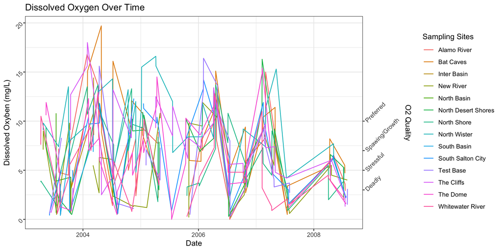

```r
oxygen_time <- ggplot(data = water_dat, aes(x = Date, y = DISS_OXYGE, color = SITE)) +
  geom_line() +
 scale_y_continuous(name = "Dissolved Oxyben (mg/L)",
                    sec.axis = sec_axis(trans = ~., # identical scale

        breaks = c(3, 5, 7, 10),
        labels = c("Deadly", "Stressful", "Spawing/Growth", "Preferred"),
        name = "O2 Quality"
        )
      ) +
  ggtitle("Dissolved Oxygen Over Time") +
  theme_bw() +
  labs(color = "Sampling Sites") +
  theme(axis.text.y = element_text(angle = 45, hjust = 1)
        )
oxygen_time
```

According to [Atlas Scientific, 2025-01-02](https://atlas-scientific.com/blog/dissolved-oxygen-in-water-ppm-for-fish/?srsltid=AfmBOooerjJwGn1hehDjYjzdmpVOnHQApUAu18rdyTxo5z3fOYdrsmak), the average dissolved oxygen concentration in seawater is around 5 to 8 mg/L.

The data shows that the dissolved oxygen levels in the Salton Sea can drop below 5 mg/L at times, which can be detrimental to the aquatic life in the area.

## Conclusion

The data from the Quarterly Water Quality Surveys at the Salton Sea provides valuable insights into the environmental conditions of the area. The analysis of salinity, temperature, and dissolved oxygen levels over time can help in understanding the health of the aquatic ecosystem and inform management decisions. The observed trends indicate fluctuations in these parameters, which may be influenced by seasonal changes and other environmental factors. Salinity levels are well above the average ocean salinity and the dissolved oxygen levels do reach below 5 mg/L at times, which can be concerning for the aquatic life in the Salton Sea. Continuous monitoring and further research are essential to assess the long-term impacts of these conditions on the ecosystem.

## References

```
1.  California Natural Resources Agency. Quarterly Water Quality Surveys - Salton Sea [ds429]. https://data.cnra.ca.gov/dataset/quarterly-water-quality-surveys-salton-sea-ds429 (accessed 11 Apr. 2025).

2.  U.S. Geological Survey. Why is the ocean salty?. https://www.usgs.gov/faqs/why-ocean-salty (2019).

3.  Atlas Scientific. Dissolved Oxygen In Water: PPM For Fish. https://atlas-scientific.com/blog/dissolved-oxygen-in-water-ppm-for-fish/ (2022).
4.  Grower Today. Tilapia Temperature Requirements. https://growertoday.com/tilapia-temperature-requirements/ (2022).

5.  California Department of Fish and Game. Salton Sea Ecosystem Restoration Plan: Evaluation of Salinity Tolerance and Availability of Selected Fish Species Potentially Suitable for Introduction to the Salton Sea Ecosystem. https://nrm.dfg.ca.gov/FileHandler.ashx?DocumentID=8905 (2005).
```